# R handout: Computer exercises lecture 5

Maarten Speekenbrink & Eva Poort

1 November 2016

## Moderation

Moderation occurs when the effect of one predictor depends on the level of another. To determine whether this is the case, you need to include an interaction between those two predictors in your model. You can either first compute this variable first and add it to your data.frame. For instance, using the questionnaire data as an example, we can assess whether age moderates the relation between height and weight (or vice versa whether height moderates the relation between age and weight), as follows:

```r
library(foreign)
dat <- as.data.frame(read.spss("2016_Questionnaire_1_cleaned.sav"))
dat$Height_Age <- dat$Height*dat$Age
mod <- lm(Weight ~ Height + Age + Height_Age,data=dat)
summary(mod)
```

```
##
## Call:
## lm(formula = Weight ~ Height + Age + Height_Age, data = dat)
##
## Residuals:
##     Min      1Q  Median      3Q     Max
## -15.750  -8.411  -3.260   3.674 108.744
##
## Coefficients:
##               Estimate Std. Error t value Pr(>|t|)
## (Intercept) -66.859330 120.752148  -0.554    0.581
## Height        0.730670   0.692100   1.056    0.293
## Age          -0.487515   4.659372  -0.105    0.917
## Height_Age    0.004543   0.026593   0.171    0.865
##
## Residual standard error: 15.77 on 136 degrees of freedom
## Multiple R-squared:  0.192,  Adjusted R-squared:  0.1741
## F-statistic: 10.77 on 3 and 136 DF,  p-value: 2.14e-06
```

There is actually an easier way, as you can specify that you want an interaction in the model formula by putting a colon (“:”) between the names of variables, as follows:

```r
mod <- lm(Weight ~ Height + Age + Height:Age,data=dat)
summary(mod)
```

```
##
## Call:
## lm(formula = Weight ~ Height + Age + Height:Age, data = dat)
##
## Residuals:
##     Min      1Q  Median      3Q     Max
## -15.750  -8.411  -3.260   3.674 108.744
##
## Coefficients:
##               Estimate Std. Error t value Pr(>|t|)
## (Intercept) -66.859330 120.752148  -0.554    0.581
## Height        0.730670   0.692100   1.056    0.293
## Age          -0.487515   4.659372  -0.105    0.917
## Height:Age    0.004543   0.026593   0.171    0.865
##
## Residual standard error: 15.77 on 136 degrees of freedom
## Multiple R-squared:  0.192,  Adjusted R-squared:  0.1741
## F-statistic: 10.77 on 3 and 136 DF,  p-value: 2.14e-06
```

If you want to include both main effects (“simple slopes”) as well as an interaction, this can be shortened further, by putting a “*" between variable names, as follows:

```r
# Height*Age is evaluated as Height + Age + Height:Age
mod <- lm(Weight ~ Height*Age,data=dat)
summary(mod)
```

```
##
## Call:
## lm(formula = Weight ~ Height * Age, data = dat)
##
## Residuals:
##     Min      1Q  Median      3Q     Max
## -15.750  -8.411  -3.260   3.674 108.744
##
## Coefficients:
##               Estimate Std. Error t value Pr(>|t|)
## (Intercept) -66.859330 120.752148  -0.554    0.581
## Height        0.730670   0.692100   1.056    0.293
## Age          -0.487515   4.659372  -0.105    0.917
## Height:Age    0.004543   0.026593   0.171    0.865
##
## Residual standard error: 15.77 on 136 degrees of freedom
## Multiple R-squared:  0.192,  Adjusted R-squared:  0.1741
## F-statistic: 10.77 on 3 and 136 DF,  p-value: 2.14e-06
```

## Correlation

To get correlations netween predictors, you can use the `cor` function. You can either use `cor(x,y)` to get the correlation between variables `x` and `y`, or use `cor(x=matrix)` where `matrix` is a matrix with variables. The latter option will give you all the pairwise correlations between the columns (variables) in the matrix:

```r
cor(dat$Age,dat$Height)
```

```
## [1] 0.1072034
```

```r
cor(dat[,c("Weight","Age","Height")])
```

```
##           Weight       Age    Height
## Weight 1.0000000 0.1307967 0.4295706
## Age    0.1307967 1.0000000 0.1072034
## Height 0.4295706 0.1072034 1.0000000
```

Correlations above .80 or .90 indicate (multi-)collinearity, though it’s usually better to look at the tolerance values (or variance inflation factors).

# Centering predictors

To center a variable (e.g. height) you can create a new variable by subtracting the mean

```r
dat$Age_c <- dat$Age - mean(dat$Age)
```

Another option is to use the `scale` function, which can be used for centering and standardizing further by also dividing by the standard deviation (so you get a Z-transformed variable).

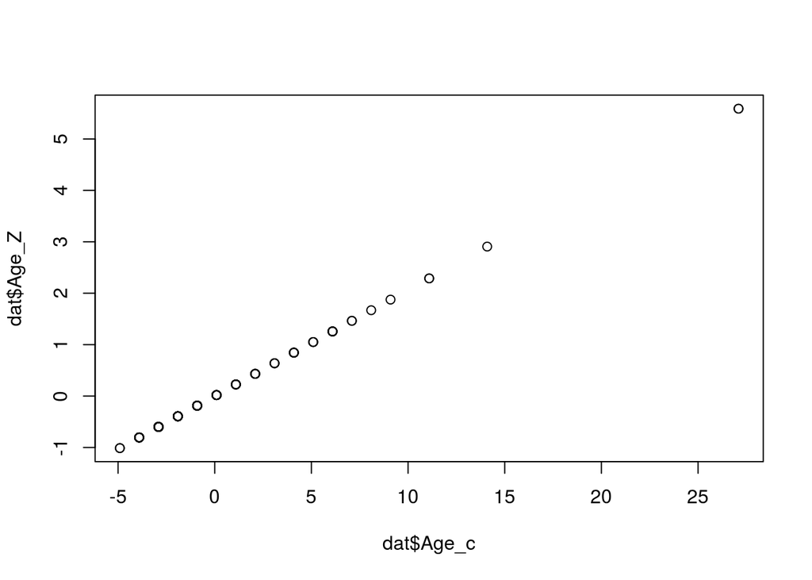

```r
# centering
dat$Age_c <- scale(dat$Age,center = TRUE, scale=FALSE)
dat$Age_Z <- scale(dat$Age)
plot(dat$Age_c,dat$Age_Z)
```

A very useful feature of R is that you can transform variables, and add interactions, without first creating new variables. For instance, the following code can be used to estimate the model specified before after centering the predictors:

```r
summary(lm(Weight ~ scale(Height,scale=FALSE)*scale(Age,scale=FALSE),data=dat))
```

```
##
## Call:
## lm(formula = Weight ~ scale(Height, scale = FALSE) * scale(Age,
##     scale = FALSE), data = dat)
##
## Residuals:
##     Min      1Q  Median      3Q     Max
## -15.750  -8.411  -3.260   3.674 108.744
##
## Coefficients:
##                                                         Estimate
## (Intercept)                                            64.519424
## scale(Height, scale = FALSE)                            0.843818
## scale(Age, scale = FALSE)                               0.285146
## scale(Height, scale = FALSE):scale(Age, scale = FALSE)  0.004543
##                                                        Std. Error t value
## (Intercept)                                              1.338458  48.204
## scale(Height, scale = FALSE)                             0.156451   5.394
## scale(Age, scale = FALSE)                                0.305733   0.933
## scale(Height, scale = FALSE):scale(Age, scale = FALSE)   0.026593   0.171
##                                                        Pr(>|t|)
## (Intercept)                                             < 2e-16 ***
## scale(Height, scale = FALSE)                           2.97e-07 ***
## scale(Age, scale = FALSE)                                 0.353
## scale(Height, scale = FALSE):scale(Age, scale = FALSE)    0.865
## ---
## Signif. codes:  0 '***' 0.001 '**' 0.01 '*' 0.05 '.' 0.1 ' ' 1
##
## Residual standard error: 15.77 on 136 degrees of freedom
## Multiple R-squared:  0.192,  Adjusted R-squared:  0.1741
## F-statistic: 10.77 on 3 and 136 DF,  p-value: 2.14e-06
```

or Z-transforming all variables:

```r
summary(lm(scale(Weight) ~ scale(Height)*scale(Age),data=dat))
```

```
##
## Call:
## lm(formula = scale(Weight) ~ scale(Height) * scale(Age), data = dat)
##
## Residuals:
##     Min      1Q  Median      3Q     Max
## -0.9073 -0.4845 -0.1878  0.2117  6.2646
##
## Coefficients:
##                           Estimate Std. Error t value Pr(>|t|)
## (Intercept)              -0.001165   0.077107  -0.015    0.988
## scale(Height)             0.419366   0.077754   5.394 2.97e-07 ***
## scale(Age)                0.079624   0.085372   0.933    0.353
## scale(Height):scale(Age)  0.010943   0.064062   0.171    0.865
## ---
## Signif. codes:  0 '***' 0.001 '**' 0.01 '*' 0.05 '.' 0.1 ' ' 1
##
## Residual standard error: 0.9088 on 136 degrees of freedom
## Multiple R-squared:  0.192,  Adjusted R-squared:  0.1741
## F-statistic: 10.77 on 3 and 136 DF,  p-value: 2.14e-06
```

## Mediation

Mediation occurs when the effect of the predictor on the dependent variable is indirect (i.e. the predictor affects the mediator which affects the dependent variable). There are two ways of assessing mediation. The first is to use the causal steps procedure, which consists of estimating three regression models as explained in the lecture. In addition, you can use the Sobel-Aroian test to test the significance of the indirect effect of $X_1$ on $Y$:

$$Z = \frac{a \times b}{\sqrt{a^2 \times s_b^2 + b^2 \times s_a^2 + s_a^2 \times s_b^2}}$$

where $a$ and $b$ are the slope estimates and $s_a^2$ and $s_b^2$ the squared standard errors of the slope estimates. You can get the precise values of these through the summary function. This function doesn’t only print results on the console, it actually returns a list with lots of values. You can see exactly what is stored by using the `str` function:

```r
str(summary(mod))
```

```
## List of 11
##  $ call         : language lm(formula = Weight ~ Height * Age, data = dat)
##  $ terms        :Classes 'terms', 'formula'  language Weight ~ Height * Age
##   .. ..- attr(*, "variables")= language list(Weight, Height, Age)
##   .. ..- attr(*, "factors")= int [1:3, 1:3] 0 1 0 0 0 1 0 1 1
##   .. .. ..- attr(*, "dimnames")=List of 2
##   .. .. .. ..$ : chr [1:3] "Weight" "Height" "Age"
##   .. .. .. ..$ : chr [1:3] "Height" "Age" "Height:Age"
##   .. ..- attr(*, "term.labels")= chr [1:3] "Height" "Age" "Height:Age"
##   .. ..- attr(*, "order")= int [1:3] 1 1 2
##   .. ..- attr(*, "intercept")= int 1
##   .. ..- attr(*, "response")= int 1
##   .. ..- attr(*, ".Environment")=<environment: R_GlobalEnv>
##   .. ..- attr(*, "predvars")= language list(Weight, Height, Age)
##   .. ..- attr(*, "dataClasses")= Named chr [1:3] "numeric" "numeric" "numeric"
##   .. .. ..- attr(*, "names")= chr [1:3] "Weight" "Height" "Age"
##  $ residuals    : Named num [1:140] -7.548 0.849 -2.07 0.448 -11.834 ...
##   ..- attr(*, "names")= chr [1:140] "1" "2" "3" "4" ...
##  $ coefficients : num [1:4, 1:4] -66.85933 0.73067 -0.48751 0.00454 120.75215 ...
##   ..- attr(*, "dimnames")=List of 2
##   .. ..$ : chr [1:4] "(Intercept)" "Height" "Age" "Height:Age"
##   .. ..$ : chr [1:4] "Estimate" "Std. Error" "t value" "Pr(>|t|)"
##  $ aliased      : Named logi [1:4] FALSE FALSE FALSE FALSE
##   ..- attr(*, "names")= chr [1:4] "(Intercept)" "Height" "Age" "Height:Age"
##  $ sigma        : num 15.8
##  $ df           : int [1:3] 4 136 4
##  $ r.squared    : num 0.192
##  $ adj.r.squared: num 0.174
##  $ fstatistic   : Named num [1:3] 10.8 3 136
##   ..- attr(*, "names")= chr [1:3] "value" "numdf" "dendf"
##  $ cov.unscaled : num [1:4, 1:4] 58.5951 -0.3353 -2.2055 0.0126 -0.3353 ...
##   ..- attr(*, "dimnames")=List of 2
##   .. ..$ : chr [1:4] "(Intercept)" "Height" "Age" "Height:Age"
##   .. ..$ : chr [1:4] "(Intercept)" "Height" "Age" "Height:Age"
##  - attr(*, "class")= chr "summary.lm"
```

The required estimates and standard errors are stored in a matrix in the element of the list called `coefficients`:

```r
summary(mod)$coefficients
```

```
##                  Estimate   Std. Error    t value  Pr(>|t|)
## (Intercept) -66.859329972 120.75214753 -0.5536906 0.5806998
## Height        0.730670285   0.69210039  1.0557288 0.2929640
## Age          -0.487514863   4.65937207 -0.1046310 0.9168227
## Height:Age    0.004542774   0.02659289  0.1708266 0.8646140
```

and you can get an element from this as follows:

```r
# s.e. of Height slope:
summary(mod)$coefficients["Height","Std. Error"]
```

```
## [1] 0.6921004
```

```r
# or
summary(mod)$coefficients[2,2]
```

```
## [1] 0.6921004
```

You can store the required numbers as e.g. `a`, `b`, `se_a`, `se_b`, and then compute the test statistic by writing a function. For instance, seeing whether the relation between age and weight is mediated by height:

```r
mod1 <- lm(Weight~Age,data=dat)
mod2 <- lm(Height~Age,data=dat)
mod3 <- lm(Weight~Height+Age,data=dat)

a <- summary(mod2)$coefficients["Age","Estimate"]
se_a <- summary(mod2)$coefficients["Age","Std. Error"]
b <- summary(mod3)$coefficients["Height","Estimate"]
se_b <- summary(mod3)$coefficients["Height","Std. Error"]

mySobelTest <- function(a,b,se_a,se_b) {
  Z <- (a*b)/sqrt((a^2 * se_b^2 + b^2 * se_a^2 + se_a^2*se_b^2))
  # two-sided p-value
  p <- 2*(1-pnorm(abs(Z)))
  cat("Sobel-Arioan Test \n")
  cat(paste("Z = ",Z,", p = ",p,"\n",sep=""))
}

mySobelTest(a,b,se_a,se_b)
```

```
## Sobel-Arioan Test
## Z = 1.21437669220778, p = 0.224603911649714
```